# Tarea 1

Carlos Crespín

2024-04-04

[figure not shown]

# Analítica Social e Inteligencia Estratégica

# Pregunta 1

Descargar los datos

```r
library(rio)
data=import("https://github.com/krlos20203563/ASIE_2024-1/raw/main/datos_abiertos_vigilancia_dengue.csv")
```

Ahora procederemos a explorar los estadísticos descriptivos

```r
summary(data$edad)
```

```
##    Min. 1st Qu.  Median    Mean 3rd Qu.    Max.
##    0.00   15.00   26.00   28.97   41.00  106.00
```

También inspeccionaré la estructura de los datos

```r
str(data)
```

```
## 'data.frame':    501680 obs. of  7 variables:
##  $ departamento: chr  "SAN MARTIN" "CUSCO" "ICA" "LORETO" ...
##  $ provincia   : chr  "RIOJA" "LA CONVENCION" "ICA" "MAYNAS" ...
##  $ distrito    : chr  "PARDO MIGUEL" "SANTA ANA" "PARCONA" "IQUITOS" ...
##  $ enfermedad  : chr  "DENGUE SIN SEÑALES DE ALARMA" "DENGUE SIN SEÑALES DE ALARMA" "DENGUE SIN SEÑALES DE ALARMA" "DENGUE SIN SEÑALES DE ALARMA" ...
##  $ year        : int  2022 2021 2020 2021 2021 2022 2020 2022 2017 2017 ...
##  $ ubigeo      : int  220805 80901 110106 160101 250101 200401 160101 200105 200104 130702 ...
##  $ edad        : int  106 105 104 104 103 103 102 101 100 100 ...
```

```r
library(dplyr)
table(data$enfermedad)
```

```
##
##                              DENGUE CON SEÑALES DE ALARMA
##                            8                        55058
##                 DENGUE GRAVE DENGUE SIN SEÑALES DE ALARMA
##                         2262                       444352
```

```r
data$enfermedad <- gsub("DENGUE CON SEÑALES DE ALARMA", "con", data$enfermedad)
data$enfermedad <- gsub("DENGUE SIN SEÑALES DE ALARMA", "sin", data$enfermedad)
data$enfermedad <- gsub("DENGUE GRAVE", "grave", data$enfermedad)
```

```r
table(data$enfermedad)
```

```
##
##           con  grave    sin
##      8  55058   2262 444352
```

```r
data=filter(data, enfermedad=="con" | enfermedad=="sin" | enfermedad=="grave")
data$enfermedad=as.factor(data$enfermedad)
```

```r
table(data$enfermedad)
```

```
##
##    con  grave    sin
##  55058   2262 444352
```

```r
summary(data$edad)
```

```
##    Min. 1st Qu.  Median    Mean 3rd Qu.    Max.
##    0.00   15.00   26.00   28.97   41.00  106.00
```

# Pregunta 2

Se procederá a verificar la edad promedio de los contagiados

Agruparé por las edades por año y calcularé un promedio de las edades por año

```r
library(lsr)
EdadxYear = data |>
  group_by(year) |>
  summarise(media = mean(edad, na.rm=T))
EdadxYear
```

```
## # A tibble: 23 × 2
##     year media
##    <int> <dbl>
##  1  2000  28.4
##  2  2001  28.9
##  3  2002  26.0
##  4  2003  28.6
##  5  2004  28.1
##  6  2005  26.3
##  7  2006  26.8
##  8  2007  28.0
##  9  2008  27.8
## 10  2009  29.6
## # ℹ 13 more rows
```

## Gráfico de líneas por edades

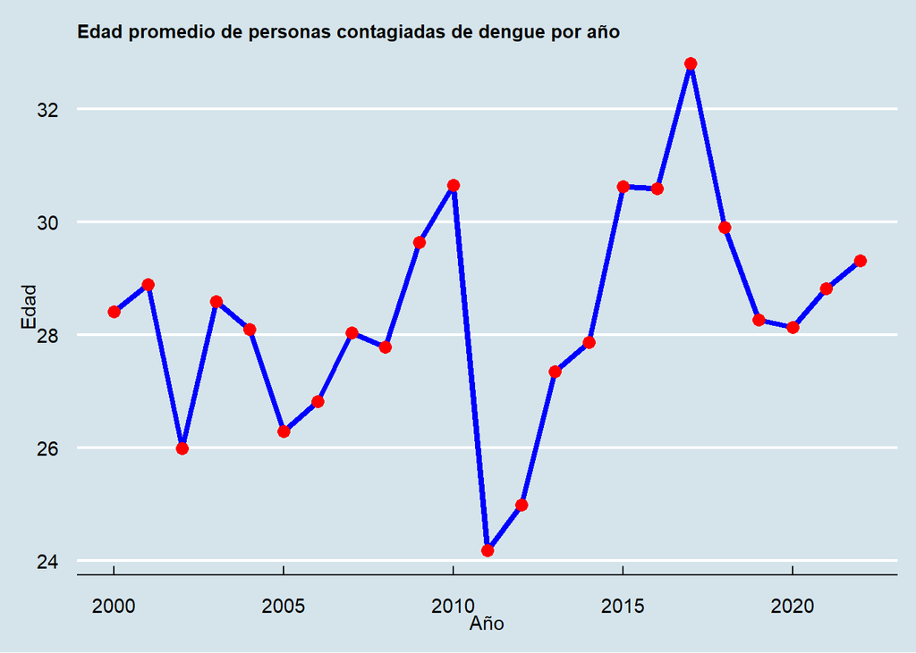

```r
library(ggplot2)
library(ggthemes)

# Crear el gráfico de líneas
library(ggplot2)

ggplot(EdadxYear, aes(x = year, y = media)) +
  geom_line(color = "blue", size = 1.5) +
  geom_point(color = "red", size = 3) +
  labs(title = "Edad promedio de personas contagiadas de dengue por año",
       x = "Año",
       y = "Edad") +
  theme_economist() +
  theme(legend.key.size = unit(1, "lines"),  # Tamaño de la leyenda
        plot.title = element_text(size = 10))  # Tamaño del título
```

# Pregunta 3

Se responderá si la cantidad de casos varió a lo largo de los años y si varió según gravedad

```r
pregunta3 <- data %>%
  group_by(year) %>%
  summarise(
    total_casos = n(),
    graves = sum(enfermedad == "grave"),
    sin_señales = sum(enfermedad == "sin"),
    con_señales = sum(enfermedad == "con")
  )
```

## Graficos

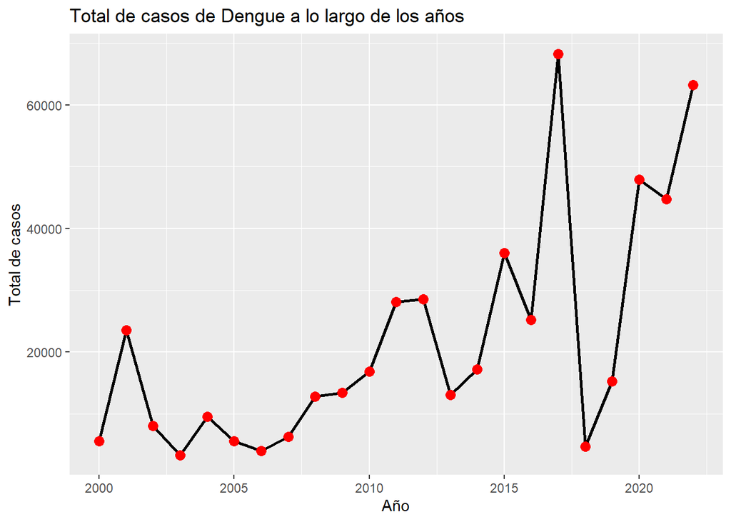

```r
library(ggplot2)
library(ggthemes)

grafico_total <- ggplot(pregunta3, aes(x = year, y = total_casos)) +
  geom_line(size=1) +
  geom_point(color = "red", size = 3) +
  labs(title = "Total de casos de Dengue a lo largo de los años",
       x = "Año",
       y = "Total de casos") +
  theme_update()

grafico_con_alarma <- ggplot(pregunta3, aes(x = year, y = con_señales)) +
  geom_line() +
  geom_point(color = "red", size = 3) +
  labs(title = "Casos de Dengue con Alarma a lo largo de los años",
       x = "Año",
       y = "Casos con Alarma") +
  theme_stata()

grafico_sin_alarma <- ggplot(pregunta3, aes(x = year, y = sin_señales)) +
  geom_line() +
  geom_point(color = "red", size = 3) +
  labs(title = "Casos de Dengue sin Alarma a lo largo de los años",
       x = "Año",
       y = "Casos sin Alarma") +
  theme_test()

grafico_graves <- ggplot(pregunta3, aes(x = year, y = graves)) +
  geom_line() +
  geom_point(color = "red", size = 3) +
  labs(title = "Casos de Dengue Grave a lo largo de los años",
       x = "Año",
       y = "Casos Graves") +
  theme_minimal()

print(grafico_total)
```

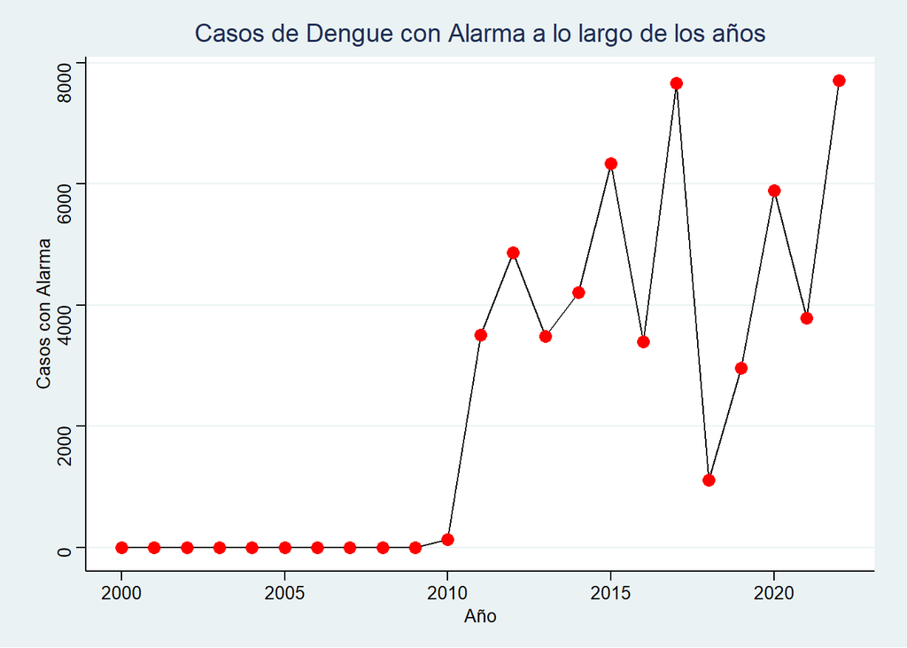

```r
print(grafico_con_alarma)
```

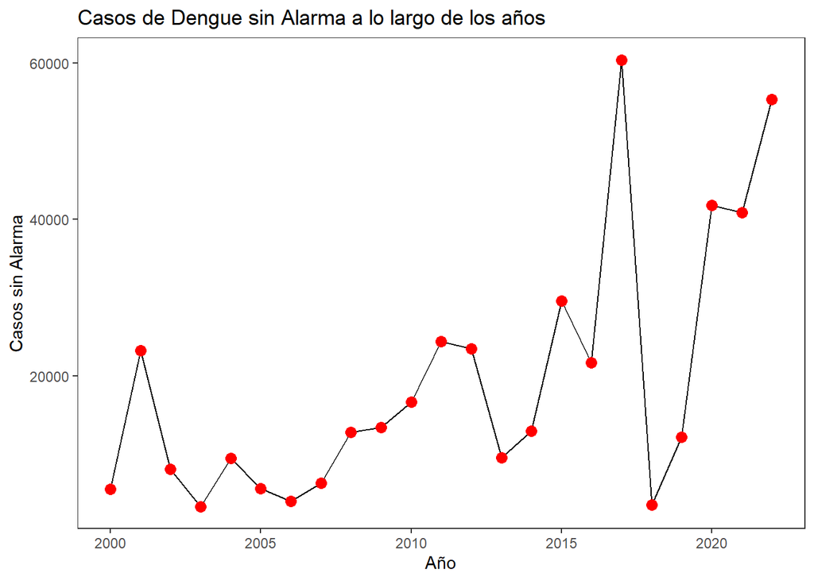

```r
print(grafico_sin_alarma)
```

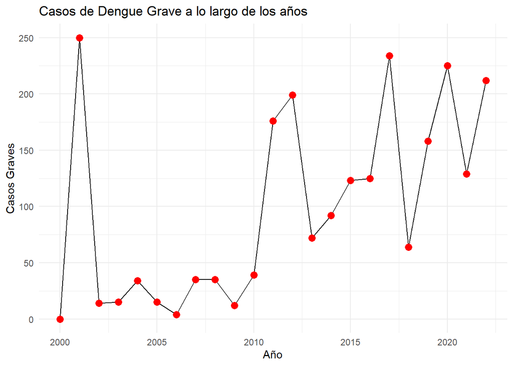

```r
print(grafico_graves)
```

# Pregunta 4

Ahora se procederá a analizar qué provincias fueron más afectadas por contagios

```r
pregunta4 <- data %>%
  group_by(departamento, provincia, year) %>%
  summarize(
    con_alarma = sum(enfermedad == "con"),
    sin_alarma = sum(enfermedad == "sin"),
    graves = sum(enfermedad == "graves")
  )
# Mostrar los primeros registros de la base de datos resumida
head(pregunta4)
```

```
## # A tibble: 6 × 6
## # Groups:   departamento, provincia [1]
##   departamento provincia  year con_alarma sin_alarma graves
##   <chr>        <chr>     <int>      <int>      <int>  <int>
## 1 AMAZONAS     BAGUA      2000          0        280      0
## 2 AMAZONAS     BAGUA      2001          0        420      0
## 3 AMAZONAS     BAGUA      2002          0         20      0
## 4 AMAZONAS     BAGUA      2003          0         83      0
## 5 AMAZONAS     BAGUA      2004          0        126      0
## 6 AMAZONAS     BAGUA      2005          0         51      0
```

Ahora añadiré el total

```r
pregunta4 <- pregunta4 %>%
  mutate(total_contagios = con_alarma + sin_alarma + graves)
head(pregunta4)
```

```
## # A tibble: 6 × 7
## # Groups:   departamento, provincia [1]
##   departamento provincia  year con_alarma sin_alarma graves total_contagios
##   <chr>        <chr>     <int>      <int>      <int>  <int>           <int>
## 1 AMAZONAS     BAGUA      2000          0        280      0             280
## 2 AMAZONAS     BAGUA      2001          0        420      0             420
## 3 AMAZONAS     BAGUA      2002          0         20      0              20
## 4 AMAZONAS     BAGUA      2003          0         83      0              83
## 5 AMAZONAS     BAGUA      2004          0        126      0             126
## 6 AMAZONAS     BAGUA      2005          0         51      0              51
```

Data nueva completa ahora sí todo

```r
provyear <- pregunta4 %>%
  group_by(departamento, provincia) %>%
  summarise(total_historico = sum(total_contagios))
summary(provyear$total_historico)
```

```
##    Min. 1st Qu.  Median    Mean 3rd Qu.    Max.
##     1.0    10.5  1138.0  4499.2  3530.5 66674.0
```

Puesto que el tercer cuartil es 3530, todos los datos que estén por encima se considerarán muy altos

```r
provyear=filter(provyear, total_historico>3530)
```

## Gráfico de puntos

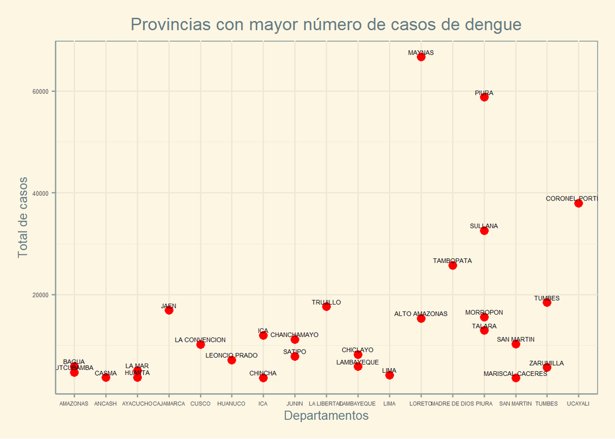

```r
library(ggplot2)

# Crear el gráfico de puntos
puntos <- ggplot(provyear, aes(x = departamento, y = total_historico, label = provincia)) +
  geom_point(color = "red", size = 3) +
  geom_text(size = 1.9, vjust = -0.5) +
  labs(title = "Provincias con mayor número de casos de dengue",
       x = "Departamentos", y = "Total de casos") +
  theme_solarized() +
  theme(plot.title = element_text(hjust = 0.5),
        plot.margin = unit(c(0.5, 0.5, 0.5, 0.5), "cm"),
        axis.text.x = element_text(size = 4.5),
        axis.text.y = element_text(size = 5),
        axis.title.x = element_text(size = 10),
        axis.title.y = element_text(size = 10))

puntos
```

# Pregunta 5

Ahora bien, para analizar la relación primero haremos una suma de cada dato por departamento y después realizaremos un heatmap (primera vez que hago uno)

Vamos a explorar primero

```r
table(data$departamento)
```

```
##
##           \\N      AMAZONAS        ANCASH      AREQUIPA      AYACUCHO
##           444         12017          7214             7          8889
##     CAJAMARCA        CALLAO         CUSCO       HUANUCO           ICA
##         19409            26         10475          9046         21324
##         JUNIN   LA LIBERTAD    LAMBAYEQUE          LIMA        LORETO
##         19199         24377         15618          4255         92496
## MADRE DE DIOS      MOQUEGUA         PASCO         PIURA          PUNO
##         30562             1          1963        126392           179
##    SAN MARTIN        TUMBES       UCAYALI
##         26759         27313         43707
```

Según lo registra la base de datos, solo se tiene información de 22 departamentos y NN

Procederemos a limpiar para después crear

```r
pregunta5 <- data %>% filter_all(all_vars(. != "\\N"))
table(pregunta5$departamento)
```

```
##
##      AMAZONAS        ANCASH      AREQUIPA      AYACUCHO     CAJAMARCA
##         12017          7214             7          8889         19409
##        CALLAO         CUSCO       HUANUCO           ICA         JUNIN
##            26         10475          9046         21324         19199
##   LA LIBERTAD    LAMBAYEQUE          LIMA        LORETO MADRE DE DIOS
##         24377         15618          4255         92496         30562
##      MOQUEGUA         PASCO         PIURA          PUNO    SAN MARTIN
##             1          1963        126392           179         26759
##        TUMBES       UCAYALI
##         27313         43707
```

Creacion de la data

```r
pregunta5 <- pregunta5 %>%
  group_by(departamento) %>%
  summarise(
    total_casos = n(),
    graves = sum(enfermedad == "grave"),
    sin_señales = sum(enfermedad == "sin"),
    con_señales = sum(enfermedad == "con")
  )
head(pregunta5)
```

```
## # A tibble: 6 × 5
##   departamento total_casos graves sin_señales con_señales
##   <chr>              <int>  <int>       <int>       <int>
## 1 AMAZONAS           12017     39       11476         502
## 2 ANCASH              7214     19        6899         296
## 3 AREQUIPA               7      0           6           1
## 4 AYACUCHO            8889     20        8600         269
## 5 CAJAMARCA          19409     37       17503        1869
## 6 CALLAO                26      0          23           3
```

La pregunta me pide analizar la relación entre casos alarmantes no graves y los asintomaticos. En ese sentido, en la base de datos significa que es la relación entre los “con” entre los “sin”

```r
pregunta5 <- pregunta5 %>%
  mutate(relacion = con_señales/sin_señales)
head(pregunta5)
```

```
## # A tibble: 6 × 6
##   departamento total_casos graves sin_señales con_señales relacion
##   <chr>              <int>  <int>       <int>       <int>    <dbl>
## 1 AMAZONAS           12017     39       11476         502   0.0437
## 2 ANCASH              7214     19        6899         296   0.0429
## 3 AREQUIPA               7      0           6           1   0.167
## 4 AYACUCHO            8889     20        8600         269   0.0313
## 5 CAJAMARCA          19409     37       17503        1869   0.107
## 6 CALLAO                26      0          23           3   0.130
```

Ahora realizaré el heatmap

```r
library(knitr)
library(heatmap3)
library(plotly)
# Preparar los datos para el heatmap
heatmap_data <- pregunta5 %>%
  select(con_señales, sin_señales, relacion) %>%
  as.matrix()
rownames(heatmap_data) <- pregunta5$departamento
```

## Heatmap de la relación

```r
library(d3heatmap)
d3heatmap(heatmap_data, scale = "column", colors="Spectral",)
```

[interactive chart not shown]